# Machine Learning with NHANES Data

Grace Ivins https://github.com/graceivins  
4/16/2020

This project uses machine learning algorithms to predict systolic blood pressure in the NHANES data set. The National Health and Nutrition Examination Survey (NHANES) has been conducted since 1971 and aims to assess the mental and physical wellbeing of children and adults in the United States. Each participant completes a questionnaire, is physically examined by a medical health professional, and undergoes laboratory tests.

I have several goals for this project. I am primarily interested in learning the basics of machine learning and how machine learning differs from my master’s discipline, statistics. Secondary goals include learning how to implement machine learning algorithms using packages in python and learning how to integrate R and Python to create reports that are useful and easy to read.

High systolic blood pressure is an important indicator of health, particularly for those over the age of 50, even when diastolic blood pressure is normal. Machine learning algortihms will allow us to use the wealth of NHANES data to predict systolic blood pressure with good accuracy. Why would we want to predict something that can be easily measured at a doctor’s office? There are several reasons we might want to predict items that are relatively easy to measure. For example, we might want to create an online tool where people could input factors they can easily measure themselves, like height, weight, and age, that then predicts their systolic blood pressure. We might also want to know what factors contribute significantly to the prediction so that health campaigns are targeted to the right groups.

```
       name                    python
1 anaconda3 /opt/anaconda3/bin/python
```

When undertaking a data project, be it in statistics or machine learning, thorough inspection and cleaning are essential. The first thing I noticed when looking at the NHANES data was that it has quite a few NaN’s. There are several options for dealing with missing values, like imputation and so forth. We will deal with them by removing any observations (rows) that include NaN’s. This will have implications as we are removing individuals from the data. However, most of the NaN’s occur in the alcohol units per day column as children were also a part of the study.

Since our concern here is systolic blood pressure, we aren’t too worried about preserving the measurements on children.

First, we have a look at the first few rows of the data.

```python
print(data.head())
```

```
    Age  HHIncomeMid  Poverty  ...  TotChol  SleepHrsNight  AlcoholDay
4    49      40000.0     1.91  ...     6.70            8.0         2.0
7    45      87500.0     5.00  ...     5.82            8.0         3.0
8    45      87500.0     5.00  ...     5.82            8.0         3.0
9    45      87500.0     5.00  ...     5.82            8.0         3.0
10   66      30000.0     2.20  ...     4.99            7.0         1.0

[5 rows x 11 columns]
```

This is a medium sized data set. We can see all variables more clearly if we “glimpse” the data instead using the tidyverse library in R:

```r
library(tidyverse)

py$data %>%
    as.tibble() %>%
    glimpse()
```

```
Rows: 4,273
Columns: 11
$ Age           <dbl> 49, 45, 45, 45, 66, 58, 54, 33, 60, 56, 56, 5…
$ HHIncomeMid   <dbl> 40000, 87500, 87500, 87500, 30000, 100000, 70…
$ Poverty       <dbl> 1.91, 5.00, 5.00, 5.00, 2.20, 5.00, 2.20, 1.2…
$ Weight        <dbl> 86.7, 75.7, 75.7, 75.7, 68.0, 78.4, 74.7, 93.…
$ Height        <dbl> 168.4, 166.7, 166.7, 166.7, 169.5, 181.9, 169…
$ BMI           <dbl> 30.57, 27.24, 27.24, 27.24, 23.67, 23.69, 26.…
$ Pulse         <dbl> 86, 62, 62, 62, 60, 62, 76, 96, 84, 64, 64, 6…
$ BPSysAve      <dbl> 112, 118, 118, 118, 111, 104, 134, 128, 152, …
$ TotChol       <dbl> 6.70, 5.82, 5.82, 5.82, 4.99, 4.24, 6.41, 5.5…
$ SleepHrsNight <dbl> 8, 8, 8, 8, 7, 5, 4, 6, 6, 7, 7, 6, 6, 6, 7, …
$ AlcoholDay    <dbl> 2, 3, 3, 3, 1, 2, 6, 3, 6, 1, 1, 2, 2, 12, 4,…
```

Let’s have a look at a correlation matrix:

```r
corr <- cor(py$data)
round(corr, 2)
```

```
                Age HHIncomeMid Poverty Weight Height   BMI Pulse
Age            1.00        0.08    0.23   0.00  -0.09  0.04 -0.18
HHIncomeMid    0.08        1.00    0.87   0.00   0.14 -0.08 -0.11
Poverty        0.23        0.87    1.00   0.00   0.12 -0.07 -0.13
Weight         0.00        0.00    0.00   1.00   0.46  0.88  0.09
Height        -0.09        0.14    0.12   0.46   1.00  0.00 -0.05
BMI            0.04       -0.08   -0.07   0.88   0.00  1.00  0.12
Pulse         -0.18       -0.11   -0.13   0.09  -0.05  0.12  1.00
BPSysAve       0.36       -0.04    0.00   0.15   0.05  0.14  0.00
TotChol        0.18        0.08    0.10  -0.03  -0.10  0.02  0.08
SleepHrsNight  0.05        0.08    0.10  -0.06  -0.04 -0.05  0.00
AlcoholDay    -0.25       -0.13   -0.19   0.10   0.15  0.03  0.06
              BPSysAve TotChol SleepHrsNight AlcoholDay
Age               0.36    0.18          0.05      -0.25
HHIncomeMid      -0.04    0.08          0.08      -0.13
Poverty           0.00    0.10          0.10      -0.19
Weight            0.15   -0.03         -0.06       0.10
Height            0.05   -0.10         -0.04       0.15
BMI               0.14    0.02         -0.05       0.03
Pulse             0.00    0.08          0.00       0.06
BPSysAve          1.00    0.15          0.00       0.00
TotChol           0.15    1.00          0.01      -0.04
SleepHrsNight     0.00    0.01          1.00      -0.09
AlcoholDay        0.00   -0.04         -0.09       1.00
```

We will exclude BMI as BMI is a ratio of height and weight.

```python
data=data.drop("BMI",axis=1)
```

Since income and poverty (defined as the ratio of family income to poverty guidelines) are highly correlated, we will also remove income as the information the variables contribute to the prediction will be redundant. If we wanted to make inference, as we often do in statistics, we would be concerned about multicollinearity. In ML, we are often primarily concerned with making predictions and so aren’t as concerned with multicollinearity.

```python
data=data.drop("HHIncomeMid",axis=1)
```

Take a peek at our new correlation matrix:

```r
corr <- cor(py$data)
round(corr, 2)
```

```
                Age Poverty Weight Height Pulse BPSysAve TotChol
Age            1.00    0.23   0.00  -0.09 -0.18     0.36    0.18
Poverty        0.23    1.00   0.00   0.12 -0.13     0.00    0.10
Weight         0.00    0.00   1.00   0.46  0.09     0.15   -0.03
Height        -0.09    0.12   0.46   1.00 -0.05     0.05   -0.10
Pulse         -0.18   -0.13   0.09  -0.05  1.00     0.00    0.08
BPSysAve       0.36    0.00   0.15   0.05  0.00     1.00    0.15
TotChol        0.18    0.10  -0.03  -0.10  0.08     0.15    1.00
SleepHrsNight  0.05    0.10  -0.06  -0.04  0.00     0.00    0.01
AlcoholDay    -0.25   -0.19   0.10   0.15  0.06     0.00   -0.04
              SleepHrsNight AlcoholDay
Age                    0.05      -0.25
Poverty                0.10      -0.19
Weight                -0.06       0.10
Height                -0.04       0.15
Pulse                  0.00       0.06
BPSysAve               0.00       0.00
TotChol                0.01      -0.04
SleepHrsNight          1.00      -0.09
AlcoholDay            -0.09       1.00
```

What’s going on with this data? Well, not much, and that can sometimes happen with data collected in the real world. We will continue to use this data set to learn more about ML. We need to do more exploratory data analysis before we can start running our model.

Let’s start with summary statistics. What we are looking for here are reasonable values. If one of our variables is Age, for example, we would be wary of a maximum of 110. The means and quantiles look reasonable except for our response variable, BPSysAve, and alcohol units per day. Notice that the third quartile (75th percentile) for the alcohol variable looks reaosnable at a value of 3 but that the maximum is 82 which is clearly an error.

```python
data.describe()
```

```
               Age      Poverty  ...  SleepHrsNight   AlcoholDay
count  4273.000000  4273.000000  ...    4273.000000  4273.000000
mean     45.142523     3.176412  ...       6.923239     2.898198
std      16.250787     1.637705  ...       1.266356     3.254093
min      18.000000     0.000000  ...       2.000000     1.000000
25%      31.000000     1.640000  ...       6.000000     1.000000
50%      44.000000     3.400000  ...       7.000000     2.000000
75%      57.000000     5.000000  ...       8.000000     3.000000
max      80.000000     5.000000  ...      12.000000    82.000000

[8 rows x 9 columns]
```

```python
data['BPSysAve'].describe()
```

```
count    4273.000000
mean      120.004915
std        16.075365
min        80.000000
25%       109.000000
50%       118.000000
75%       128.000000
max       212.000000
Name: BPSysAve, dtype: float64
```

Outliers can be an important consideration before applying many machine learning algorithms. Ideally, we would like all of our data points to make equivalent contributions to our predictions rather than allowing one or a handfull of observations to skew the results. We will deal with outliers before we conduct our analyses by standardizing our data and exluding values that are more than three standard deviations away from the mean.

```python
z_scores = sc.stats.zscore(data)
abs_z_scores = np.abs(z_scores)
filtered_entries = (abs_z_scores < 3).all(axis=1)
data = data[filtered_entries]
```

Let’s look at those summary stats again to check that the values, particularly for alcohol units per day and systolic BP, look more reaosnable. Notice now that the maximum number of alcohol units per day is still quite high at 12 units, but not so high that no human being could possibly consume the amount in one day.

```python
data.describe()
```

```
               Age      Poverty  ...  SleepHrsNight   AlcoholDay
count  4046.000000  4046.000000  ...    4046.000000  4046.000000
mean     44.999011     3.206112  ...       6.943648     2.710578
std      16.107534     1.621730  ...       1.175265     2.205515
min      18.000000     0.000000  ...       4.000000     1.000000
25%      31.000000     1.690000  ...       6.000000     1.000000
50%      44.000000     3.400000  ...       7.000000     2.000000
75%      57.000000     5.000000  ...       8.000000     3.000000
max      80.000000     5.000000  ...      10.000000    12.000000

[8 rows x 9 columns]
```

```python
data['BPSysAve'].describe()
```

```
count    4046.000000
mean      119.081562
std        14.177308
min        80.000000
25%       109.000000
50%       118.000000
75%       128.000000
max       168.000000
Name: BPSysAve, dtype: float64
```

Another important consideration is the overall distribution of the variables, particularly for the response variable, BPSysAve. The variables poverty and alcohol units per day are heavily skewed. It does look like average systolic blood pressure is approximately normal. In statistics, it is important that assumptions like normality of the response variable are met before conducting certain types of analyses like regression. In ML, we may not be as concerned with these assumptions.

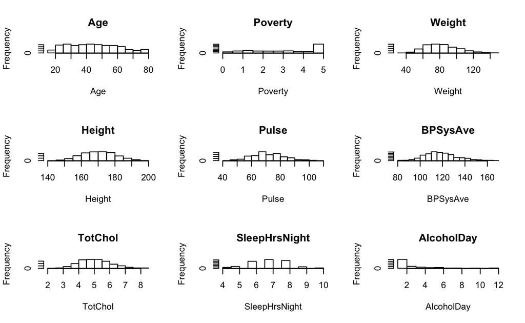

```r
par(mfrow=c(3,3))
for (i in 1:ncol(py$data)){
  hist(py$data[,i],main=colnames(py$data[i]),xlab=colnames(py$data[i]))
}
```

Regression is one of two types of supervised machine learning. The other is classification (where the outcome is categorical or discrete-valued). Regression may be an appropriate model in this case as our outcome is continuous and quantitative. When we are finished with the analysis, we will have to assess the model’s utility and determine whether the fit is good.

To get started, we will split the data into a test set and a training set. The test_size option indicates what proportion of the data will be used as the test set. The random_state option indicates what seed will be used.

```python
y = data.BPSysAve
X = data.drop("BPSysAve", axis=1)
X_train, X_test, y_train, y_test = train_test_split(
  X, y,
  test_size    = 0.2,
  random_state = 100
)
```

Now, we need to transform the data. Regression ML algorithms can be sensitive to large differences in magnitudes across variables. We standardize the values, $x$ by subtracting the mean of that particular variable, $\mu$, and dividing by the standard deviation, $\sigma$.

$$z=(x-\mu)/\sigma$$

Technically, $\mu$ and $\sigma$ are quantities in the population that we can never truly know. We will use our training set to approximate these values and then apply the same transformation to our test set.

```python
scaler = preprocessing.StandardScaler().fit(X_train)
```

After standardizing, the mean should be near 0 and the standard deviaiton should be near 1. Let’s check whether this is approximately true.

```python
X_test_scaled = scaler.transform(X_test)
X_test_scaled.mean(axis=0)
```

```
array([-0.03357853,  0.02704362,  0.06372841,  0.039864  ,  0.11003322,
       -0.0250967 ,  0.08111811, -0.04765636])
```

```python
X_test_scaled.std(axis=0)
```

```
array([0.9730581 , 0.98912975, 1.04446018, 0.98771586, 0.97825397,
       0.96004476, 0.92396155, 0.88729024])
```

Now, we will begin the training phase for our first model choice, multiple linear regression. Using the code below, we are telling our machine to learn which coefficients for each term will allow us to make the best predictions for our outcome, average systolic blood pressure. In other words, the function LinearRegression() minimizes the residual sum of squares. If we implement regression in this way, we are doing exactly what statisticians do when they run a linear regression model. The only differences are in how we will use our model output and the fact that we split our data into a test set and training set. That being said, these practices are also fairly commonly done in statistics as well.

```python
regressor=LinearRegression()
regressor.fit(X_train,y_train)
```

```
LinearRegression(copy_X=True, fit_intercept=True, n_jobs=None, normalize=False)
```

Let’s see what coefficients have been chosen:

```python
coeff_df = pd.DataFrame(regressor.coef_, X.columns, columns=['Coefficient'])
coeff_df
```

```
               Coefficient
Age               0.332020
Poverty          -0.319891
Weight            0.109385
Height            0.047154
Pulse             0.020478
TotChol           0.938724
SleepHrsNight    -0.029051
AlcoholDay        0.781411
```

Using our test set, we will make predictions for our response variable using the coefficients above:

```python
y_pred = regressor.predict(X_test)
```

We want to see how well our model fits. Let’s compute and examine our residuals. A residual is the difference between the observed value in a data set and a predicted value. Let’s create a data frame that collects and stores our fitted and predicted values.

```python
df = pd.DataFrame({'Actual': y_test, 'Predicted': y_pred})
df.head(25)
```

```
      Actual   Predicted
5772   124.0  130.200232
3751   129.0  109.544942
9453   110.0  112.815415
7228   110.0  115.669393
8863   118.0  123.624510
341    116.0  113.484389
7110   116.0  121.029678
3201   117.0  111.256623
2296   127.0  120.151140
7112   115.0  111.773652
6949   141.0  127.165931
2984   112.0  122.682442
3017   118.0  123.447935
3669   101.0  117.052685
1100   110.0  113.104782
8655   153.0  126.999284
6301   118.0  121.913317
9697   128.0  121.768081
2182   102.0  115.427574
7472   102.0  116.448853
2643   143.0  125.105978
1222   126.0  124.764779
8054   104.0  126.649657
1547   119.0  124.590973
3815   128.0  119.891230
```

```python
df.describe()
```

```
           Actual   Predicted
count  810.000000  810.000000
mean   118.991358  118.974291
std     13.875704    5.706962
min     81.000000  105.239108
25%    110.000000  114.539934
50%    118.000000  119.165046
75%    127.000000  123.278269
max    164.000000  133.732486
```

Notice that the maximum predicted value is about 134 and the maximum observed value is 164. This suggests that the model may not be fitting well on the extremes. Let’s use ggplot2 in R to plot the observed and predicted values against one another:

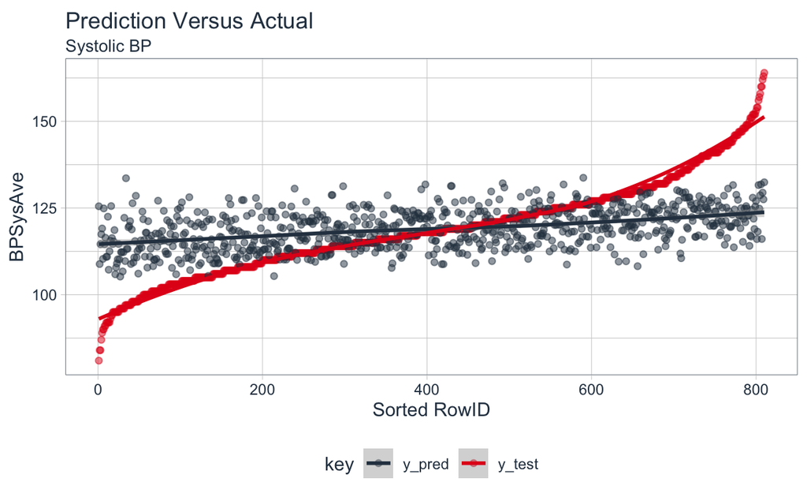

```r
library(tidyverse)
library(tidyquant) # for theme_tq()

# Manipulate data for ggplot
results_tbl <- tibble(
    y_test = py$y_test,
    y_pred = py$y_pred
) %>%
    rowid_to_column() %>%
    arrange(y_test) %>%
    mutate(rowid = as_factor(as.character(rowid))) %>%
    rowid_to_column("sorted_rowid") %>%
    gather(key = "key", value = "value", -c(rowid, sorted_rowid))

# Make ggplot
results_tbl %>%
    ggplot(aes(sorted_rowid, value, color = key)) +
    geom_point(alpha = 0.5) +
    geom_smooth() +
    theme_tq() +
    scale_color_tq() +
    labs(
        title = "Prediction Versus Actual",
        subtitle = "Systolic BP",
        x = "Sorted RowID", y = "BPSysAve"
    )
```

You can fairly easily see in the plot that this is not at all a good fit, especially for values on the extreme ends. Let’s have a look at the residuals:

```r
residuals=py$y_test-py$y_pred
mean(residuals)
```

```
[1] 0.01706744
```

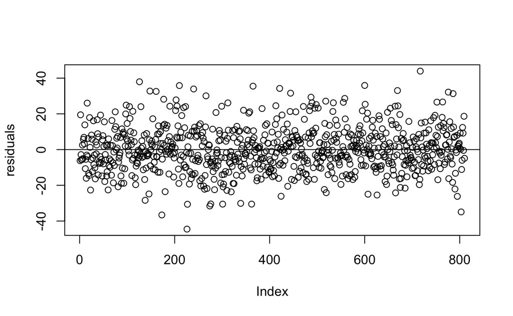

```r
plot(residuals)
abline(h=0)
```

Ideally, we would like the mean of the residuals to be near 0, and they are. Also the residual plot looks pretty good. So, it looks like our model isn’t fitting the extremes well, but it is misfitting them consistently. This would be a problem if we want to be able to predict extreme values. Let’s get a value of $R^2$ for the multiple linear regression model. $R^2$ gives the proportion of variability in the response that is explained by the predictor variables.

```python
print(r2_score(y_test, y_pred))
```

```
0.1873035149237403
```

For this model, about 19% of the variability in the response is explained by the predictors. Let’s try another model. Random forest regression is another popular machine learning algorithm that is easy to implement in python.

Like linear regression, random forest regression is a supervised learning algorithm, meaning that inputs and outputs are clearly defined. Unlike linear regression, random forest regression is an ensemble learning algorithm. This means that predictions from many regression trees will be averaged. Regression trees discretize the values of the predictors and choose how to do that such that the residual sum of squares is minimized. This technique uses bootstrapping where random samples are taken with replacement and the trees run in parallel, independently of one another, until the results are averaged.

To set up random forest egression in python, we can scale and set up the model simultaneously using a pipeline. Here n_estimators gives the number of trees. Generally, the more trees you have the better your predictions will be, but there is a point where predictions get only marginally better with too great a cost in computation time. To choose 100 trees, I checked the fit for 10, 100, and 200 trees and determined that 100 was optimal based on time of computation and accuracy of predictions.

```python
pipeline = make_pipeline(
    preprocessing.StandardScaler(),
    RandomForestRegressor(n_estimators = 100)
    )
```

In the code below the hyperparameters, maximum features and maximum depth, are given multiple options from which to choose. Maximum features gives the number of features or variables to consider when looking for the best split. The option are “auto”, max_features=number of predictor variables, “sqrt”, max_features=square root of the number of variables in the data set, and “log2”, max_features=log base 2 of the number of predictor variables in the data.

The hyperparameter max_depth gives the maximum depth of the tree. The depth of a decision tree is the length of the longest path from a root to a leaf. This can take integer values or “None”. If “None” is chosen, then nodes are expanded until all leaves are pure, in other words when all of the data belongs to a single class, or discretized group in this case as all of our predictors are quantitative.

```python
hyperparameters = {
    "randomforestregressor__max_features" : ["auto", "sqrt", "log2"],
    "randomforestregressor__max_depth"    : [None, 5, 3, 1]
}
```

GridSearchCV exhaustively searchers for the optimal values of the hyperparameters by trying all combinations. When cv=None, the grid search is completed using 5-fold cross validation (CV). Cross validation is essentially a model validation technique that is used when prediction is the goal. In general, $k$-fold CV partitions the data into $k$ subsets. Below, we have set cv=10, so we are using 10-fold CV.

```python
clf = GridSearchCV(pipeline, hyperparameters, cv = 10)
clf.fit(X_train, y_train)
```

```
GridSearchCV(cv=10, error_score=nan,
             estimator=Pipeline(memory=None,
                                steps=[('standardscaler',
                                        StandardScaler(copy=True,
                                                       with_mean=True,
                                                       with_std=True)),
                                       ('randomforestregressor',
                                        RandomForestRegressor(bootstrap=True,
                                                              ccp_alpha=0.0,
                                                              criterion='mse',
                                                              max_depth=None,
                                                              max_features='auto',
                                                              max_leaf_nodes=None,
                                                              max_samples=None,
                                                              min_impurity_decrease=0.0,
                                                              min_impurity_...
                                                              min_weight_fraction_leaf=0.0,
                                                              n_estimators=100,
                                                              n_jobs=None,
                                                              oob_score=False,
                                                              random_state=None,
                                                              verbose=0,
                                                              warm_start=False))],
                                verbose=False),
             iid='deprecated', n_jobs=None,
             param_grid={'randomforestregressor__max_depth': [None, 5, 3, 1],
                         'randomforestregressor__max_features': ['auto', 'sqrt',
                                                                 'log2']},
             pre_dispatch='2*n_jobs', refit=True, return_train_score=False,
             scoring=None, verbose=0)
```

```python
print(clf.best_params_)
```

```
{'randomforestregressor__max_depth': None, 'randomforestregressor__max_features': 'sqrt'}
```

```python
y_pred = clf.predict(X_test)
print(r2_score(y_test, y_pred))
```

```
0.5536751247109362
```

```python
print(mean_squared_error(y_test, y_pred))
```

```
85.82713814814817
```

Let’s have a look at our observed and predicted values:

```python
df = pd.DataFrame({'Actual': y_test, 'Predicted': y_pred})
df.head(25)
```

```
      Actual  Predicted
5772   124.0     125.59
3751   129.0     125.55
9453   110.0     110.18
7228   110.0     110.28
8863   118.0     117.30
341    116.0     112.34
7110   116.0     118.17
3201   117.0     115.80
2296   127.0     123.58
7112   115.0     110.19
6949   141.0     140.87
2984   112.0     120.94
3017   118.0     118.76
3669   101.0     102.53
1100   110.0     109.80
8655   153.0     150.65
6301   118.0     118.97
9697   128.0     127.09
2182   102.0     112.01
7472   102.0     108.77
2643   143.0     143.00
1222   126.0     125.63
8054   104.0     111.31
1547   119.0     119.91
3815   128.0     124.34
```

```python
df.describe()
```

```
           Actual   Predicted
count  810.000000  810.000000
mean   118.991358  118.856358
std     13.875704    9.069861
min     81.000000   87.240000
25%    110.000000  112.955000
50%    118.000000  118.460000
75%    127.000000  124.100000
max    164.000000  154.180000
```

We’ll also plot our observed values against our predicted values:

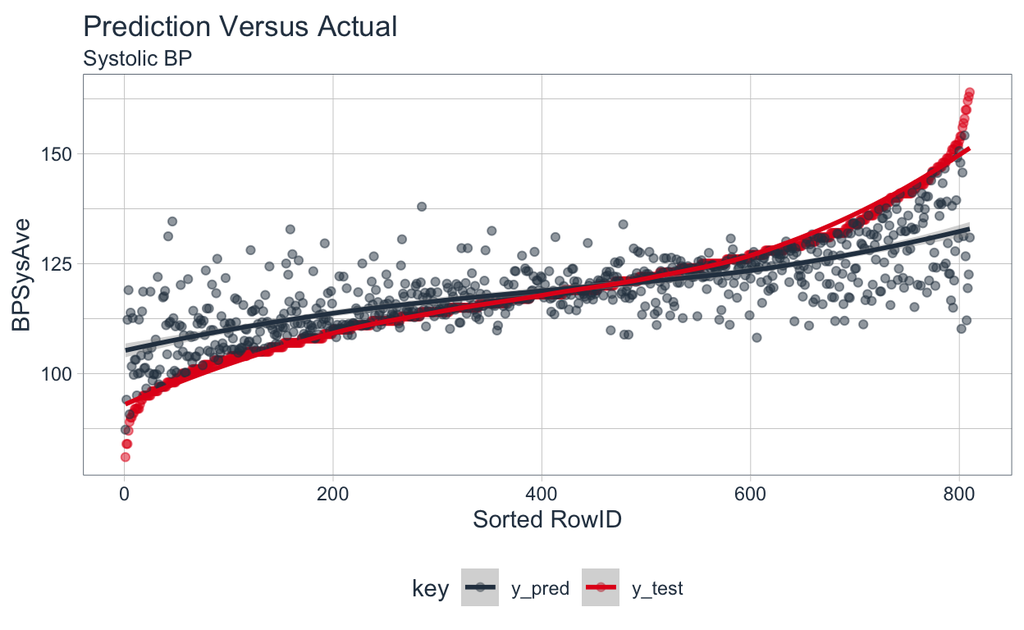

```r
library(tidyverse)
library(tidyquant) # for theme_tq()

# Manipulate data for ggplot
results_tbl <- tibble(
    y_test = py$y_test,
    y_pred = py$y_pred
) %>%
    rowid_to_column() %>%
    arrange(y_test) %>%
    mutate(rowid = as_factor(as.character(rowid))) %>%
    rowid_to_column("sorted_rowid") %>%
    gather(key = "key", value = "value", -c(rowid, sorted_rowid))

# Make ggplot
results_tbl %>%
    ggplot(aes(sorted_rowid, value, color = key)) +
    geom_point(alpha = 0.5) +
    geom_smooth() +
    theme_tq() +
    scale_color_tq() +
    labs(
        title = "Prediction Versus Actual",
        subtitle = "Systolic BP",
        x = "Sorted RowID", y = "BPSysAve"
    )
```

A look at the residuals:

```r
residuals=py$y_test-py$y_pred
mean(residuals)
```

```
[1] 0.135
```

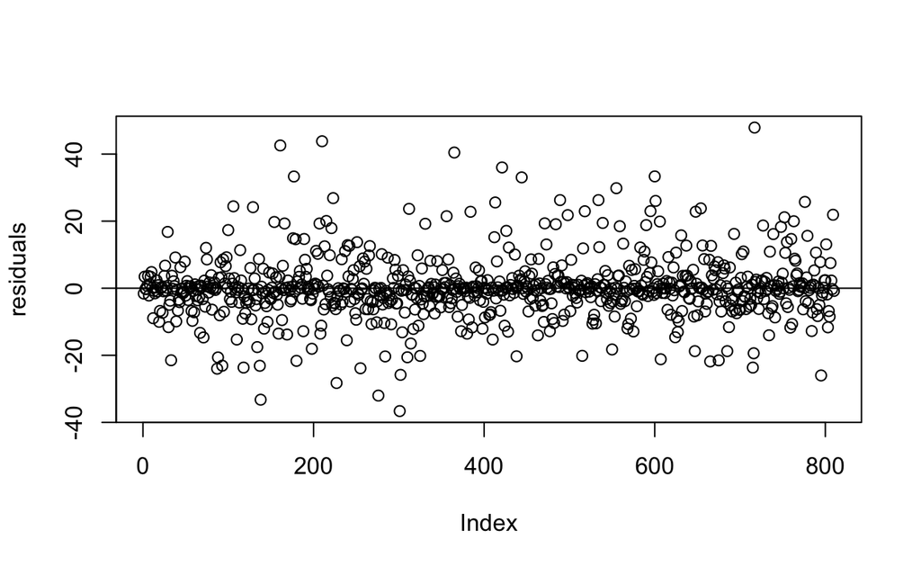

```r
plot(residuals)
abline(h=0)
```